# Model Fitting and Forecasting

Mini-project in SF2943 Time Series Analysis

Amit Alam, Ghassan Alrheis, Mark Guban, Alva Liu, Henrik Söderheilm

```r
library(itsmr, quietly = TRUE)
library(forecast, quietly = TRUE)
library(tseries, quietly = TRUE)
```

## Data Exploration

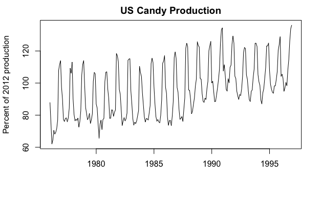

```r
data <- read.csv("~/Downloads/candy_production.csv")[[2]]
ts <- tsclean(ts(data, c(1972,1),c(2017,8), frequency=12))
ts <- window(ts, c(1976,1),c(1996,12), frequency=12)
plot(ts, main="US Candy Production", xlab= "", ylab="Percent of 2012 production")
```

It is possible to see from the plotted data that it is not stationary, it has a clear seasonal pattern as well as an increasing linear trend. The ACF and PACF indicate that the time series is seasonal as well.

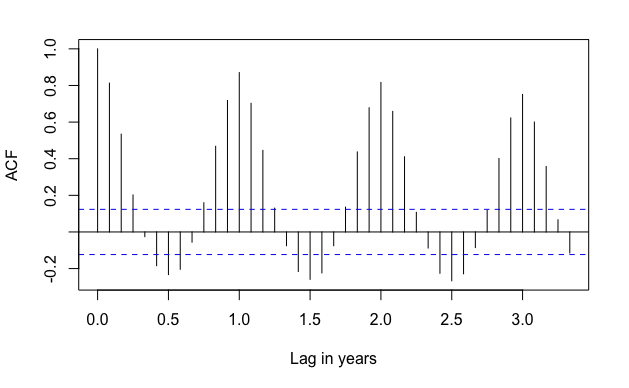

```r
acf(ts, lag.max = 40, main="", xlab = "Lag in years")
```

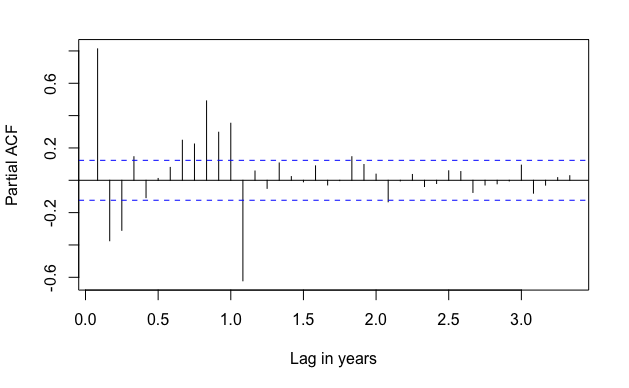

```r
pacf(ts, lag.max = 40, main="", xlab = "Lag in years")
```

```r
nsdiffs(ts)
```

```
[1] 1
```

```r
ndiffs(ts, test = "adf")
```

```
Error in xy.coords(x, y, setLab = FALSE) : 'x' and 'y' lengths differ
```

## Removing Trend and Seasonal Components From Data

After removing a seasonal component of period 12 and a linear trend from the data, we can observe in the figure below that the data is now centered around zero, but the residuals are clearly still dependent.

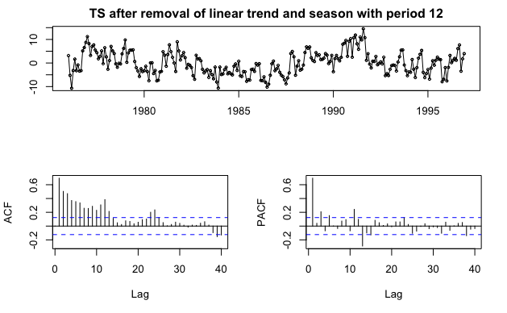

```r
clean <- ts - season(ts, 12) - trend(ts-season(ts, 12), 1)
tsdisplay(clean, main = "TS after removal of linear trend and season with period 12", lag.max = 40)
```

```r
nsdiffs(clean)
```

```
[1] 0
```

```r
ndiffs(clean, test="adf")
```

```
Error in xy.coords(x, y, setLab = FALSE) : 'x' and 'y' lengths differ
```

## Model Fitting

The last 12 data points are removed from the data in order to be used for verifying the accuracy of the predictions.

```r
model_data <- window(clean, c(1976,1), c(1995,12))
holdout <- window(clean, c(1996,1), c(1996,12))
```

Since the residuals are clearly still dependent, we need to find a stationary process that can model it. From the ACF and PACF of the data with removed the trend and seasonal components, we can see that an AR(13)-process with some coefficients set to zero might be a good fit since the ACF looks like an AR-process and the PACF has significant spikes up to lag 13. We use the Arima function from the forecast package to fit the data to an AR(13)-process and inspect the coefficients in order to determine if some of the coefficients can be fixed to zero for further optimization.

```r
Arima(model_data, order = c(13,0,0))
```

```
Series: model_data
ARIMA(13,0,0) with non-zero mean

Coefficients:
         ar1      ar2     ar3      ar4     ar5      ar6      ar7     ar8     ar9
      0.7272  -0.0862  0.1091  -0.0634  0.1405  -0.0359  -0.0463  0.0070  0.1135
s.e.  0.0605   0.0732  0.0742   0.0740  0.0742   0.0742   0.0741  0.0743  0.0738
         ar10    ar11    ar12     ar13     mean
      -0.1604  0.1224  0.3516  -0.3498  -0.2035
s.e.   0.0741  0.0748  0.0752   0.0631   1.0973

sigma^2 estimated as 9.448:  log likelihood=-604.66
AIC=1239.33   AICc=1241.47   BIC=1291.53
```

```r
fit <- Arima(model_data, order = c(13,0,0), fixed = c(NA, 0, NA, 0, NA, 0, 0, 0, NA, NA, NA, NA, NA, 0), transform.pars = FALSE)
fit
```

```
Series: model_data
ARIMA(13,0,0) with non-zero mean

Coefficients:
         ar1  ar2     ar3  ar4     ar5  ar6  ar7  ar8     ar9     ar10    ar11
      0.6787    0  0.0391    0  0.0723    0    0    0  0.0975  -0.1611  0.1098
s.e.  0.0496    0  0.0537    0  0.0508    0    0    0  0.0610   0.0724  0.0724
        ar12     ar13  mean
      0.3692  -0.3655     0
s.e.  0.0725   0.0620     0

sigma^2 estimated as 9.584:  log likelihood=-606.36
AIC=1230.72   AICc=1231.51   BIC=1262.05
```

We carry out the following tests for randomness of the model residuals in order to confirm that the AR(13)-process is a good fit for the data.

```
Null hypothesis: Residuals are iid noise.
Test                        Distribution Statistic   p-value
Ljung-Box Q                Q ~ chisq(20)      13.1    0.8733
McLeod-Li Q                Q ~ chisq(20)     26.26    0.1574
Turning points T  (T-158.7)/6.5 ~ N(0,1)       153    0.3839
Diff signs S      (S-119.5)/4.5 ~ N(0,1)       122    0.5769
Rank P          (P-14340)/621.6 ~ N(0,1)     14399    0.9244
```

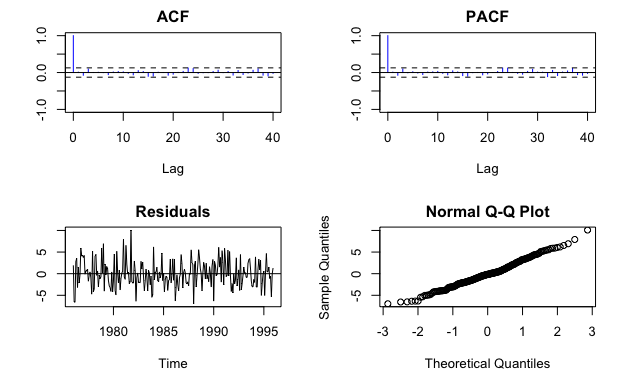

```r
test(fit$residuals)
```

The results from the Ljung-Box, McLeod-Li, Turning points and Rank tests all gives p-values above 0.05, which gives us no reason to reject the null hypothesis that the residuals are iid noise. Furthermore, the ACF and PACF are all within bounds up to lag 40 which suggest that the model is a good fit. The QQ plot shows that the model residuals are approximatedly normally distributed.

## Forecasting

Forecasts of 12 data points are plotted in blue in the figure below with a 95 % confidence level. The true values are plotted in black. We can see that the forecasted values follow the fluctuation patterns of the real data but with smaller amplitudes.

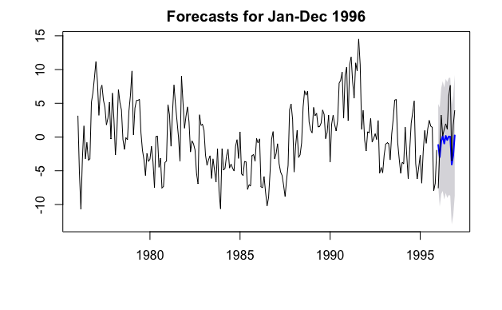

```r
f <- forecast(fit, level=95, h=12)
plot(f, main="Forecasts for Jan-Dec 1996")
lines(holdout)
```

```r
library(TSPred)
MSE(f$mean, holdout)
```

```
[1] 16.29593
```